# Reproducible Research/ Peer Assessment 1

### Loading and preprocessing the data

```r
activity <- read.csv("E:/WORKS/R/Repr/activity.csv")
str(activity)
```

```
## 'data.frame':    17568 obs. of  3 variables:
##  $ steps   : int  NA NA NA NA NA NA NA NA NA NA ...
##  $ date    : Factor w/ 61 levels "2012-10-01","2012-10-02",..: 1 1 1 1 1 1 1 1 1 1 ...
##  $ interval: int  0 5 10 15 20 25 30 35 40 45 ...
```

Calculate the total number of steps taken per day

```r
steps_by_day <- aggregate(activity$steps, by=list(activity$date), FUN=sum)
colnames(steps_by_day) <- c("Date","Steps")
```

### A histogram of the total number of steps taken each day

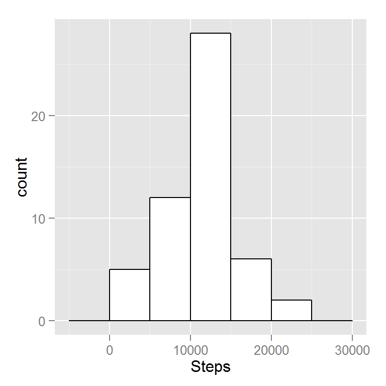

```r
library(ggplot2)
ggplot(steps_by_day, aes(x=Steps)) + geom_histogram(binwidth=5000, colour="black", fill="white")
```

### Mean and median of the total number of steps taken per day

```r
steps_mean <-   as.factor(mean(x=steps_by_day$Steps,na.rm = TRUE))
steps_median <- as.factor(median(x=steps_by_day$Steps,na.rm = TRUE))
```

Steps mean of steps taken per date is **10766.1886792453**.

Steps median of steps taken per date is **10765**.

### The average daily activity pattern

```r
steps_by_interval <- aggregate(activity$steps, by=list(activity$interval), FUN=mean, na.rm = T)
colnames(steps_by_interval) <- c("Interval","Avg_Steps")
str(steps_by_interval)
```

```
## 'data.frame':    288 obs. of  2 variables:
##  $ Interval : int  0 5 10 15 20 25 30 35 40 45 ...
##  $ Avg_Steps: num  1.717 0.3396 0.1321 0.1509 0.0755 ...
```

Which 5-minute interval, on average across all the days in the dataset, contains the maximum number of steps?

```r
max_steps_int <- steps_by_interval[which.max(steps_by_interval$Avg_Steps), ]$Interval
```

The 5-minute interval with maximum number of steps is **835**.

We will make a time series plot of the 5-minute interval (x-axis) and the average number of steps taken, averaged across all days (y-axis)

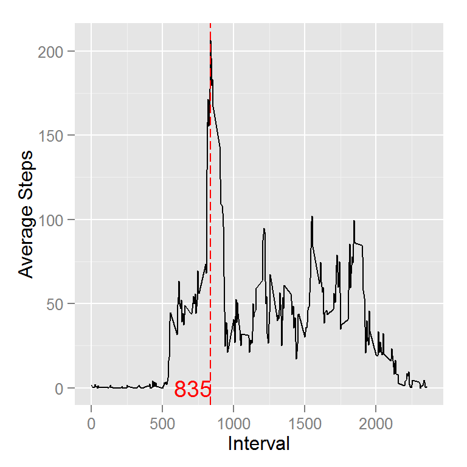

```r
ggplot(steps_by_interval, aes(x=Interval, y=Avg_Steps)) + geom_line()+
geom_vline(xintercept = max_steps_int, colour="red", linetype = "longdash")+
  xlab("Interval") +ylab("Average Steps") +
  annotate("text", x = max_steps_int-120, y = 0, label = max_steps_int,colour = "red")
```

Note: in RED is 5-minute interval with maximum number of steps.

### Imputing missing values

Calculate and report the total number of missing values in the dataset

```r
summary(activity$steps)
```

```
##    Min. 1st Qu.  Median    Mean 3rd Qu.    Max.    NA's
##    0.00    0.00    0.00   37.38   12.00  806.00    2304
```

```r
str(activity$steps)
```

```
##  int [1:17568] NA NA NA NA NA NA NA NA NA NA ...
```

We will use mean value to filling in all of the missing values in the dataset.

```r
mean_steps <- mean(activity$steps, na.rm=T)
activity$steps <- ifelse(is.na(activity$steps),mean_steps,activity$steps)
summary(activity$steps)
```

```
##    Min. 1st Qu.  Median    Mean 3rd Qu.    Max.
##    0.00    0.00    0.00   37.38   37.38  806.00
```

```r
str(activity$steps)
```

```
##  num [1:17568] 37.4 37.4 37.4 37.4 37.4 ...
```

### A histogram of the total number of steps taken each day

Calculate the total number of steps taken per day

```r
steps_by_day <- aggregate(activity$steps, by=list(activity$date), FUN=sum)
colnames(steps_by_day) <- c("Date","Steps")
```

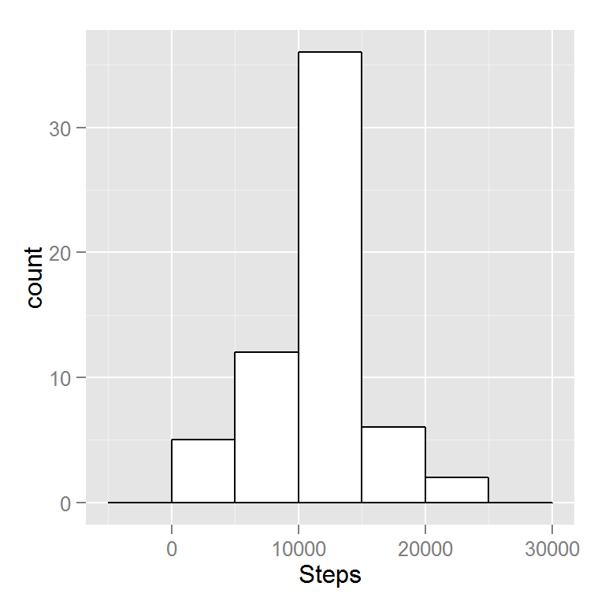

```r
library(ggplot2)
ggplot(steps_by_day, aes(x=Steps)) + geom_histogram(binwidth=5000, colour="black", fill="white")
```

### Mean and median of the total number of steps taken per day

```r
steps_mean <-   as.factor(mean(x=steps_by_day$Steps,na.rm = TRUE))
steps_median <- as.factor(median(x=steps_by_day$Steps,na.rm = TRUE))
```

Steps mean of steps taken per date is **10766.1886792453**.

Steps median of steps taken per date is **10766.1886792453**.

1. Do these values differ from the estimates from the first part of the assignment? The mean remains the same but the median increased.
2. What is the impact of imputing missing data on the estimates of the total daily number of steps? The total daily number of steps is increased after inputting missing data.

### The differences in activity patterns between weekdays and weekends

We will Create a new factor variable in the dataset with two levels – “weekday” and “weekend” indicating whether a given date is a weekday or weekend day.

```r
Sys.setlocale("LC_TIME", "English")
```

```
## [1] "English_United States.1252"
```

```r
activity$Date_IND <- as.factor(ifelse(weekdays(as.Date(activity$date, format = "%Y-%m-%d")) %in%  c("Saturday","Sunday"), "Weekend", "Weekday"))
str(activity)
```

```
## 'data.frame':    17568 obs. of  4 variables:
##  $ steps   : num  37.4 37.4 37.4 37.4 37.4 ...
##  $ date    : Factor w/ 61 levels "2012-10-01","2012-10-02",..: 1 1 1 1 1 1 1 1 1 1 ...
##  $ interval: int  0 5 10 15 20 25 30 35 40 45 ...
##  $ Date_IND: Factor w/ 2 levels "Weekday","Weekend": 1 1 1 1 1 1 1 1 1 1 ...
```

```r
steps_by_interval_DAY <- aggregate(activity$steps, by=list(activity$interval,activity$Date_IND), FUN=mean, na.rm = T)
colnames(steps_by_interval_DAY) <- c("Interval","DAY_IND","Avg_Steps")
str(steps_by_interval_DAY)
```

```
## 'data.frame':    576 obs. of  3 variables:
##  $ Interval : int  0 5 10 15 20 25 30 35 40 45 ...
##  $ DAY_IND  : Factor w/ 2 levels "Weekday","Weekend": 1 1 1 1 1 1 1 1 1 1 ...
##  $ Avg_Steps: num  7.01 5.38 5.14 5.16 5.07 ...
```

A panel plot containing a time series plot of the 5-minute interval (x-axis) and the average number of steps taken, averaged across all weekday days or weekend days (y-axis).

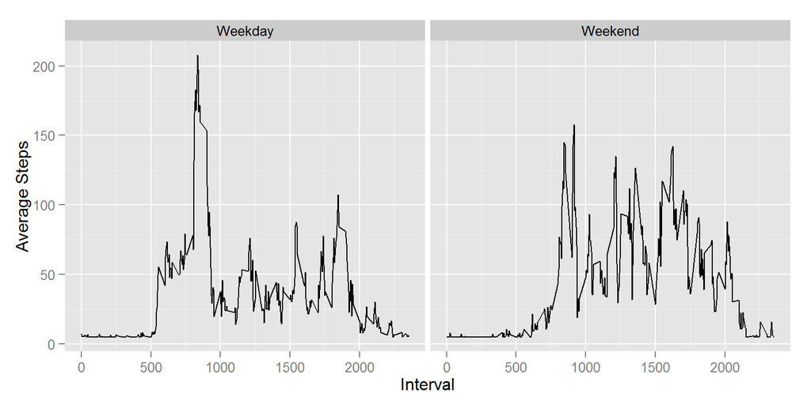

```r
ggplot(steps_by_interval_DAY, aes(x=Interval, y=Avg_Steps)) + geom_line()+
  facet_wrap(~DAY_IND)+
  xlab("Interval") +ylab("Average Steps")
```